# DASI_Project

Tuesday, October 14, 2014

### Part 1 Introduction:

The U.S. subprime mortgage crisis was a nationwide banking emergency that coincided with the U.S. recession of December 2007-June 2009.[3] There were many causes of the crisis, with commentators assigning different levels of blame to financial institutions, regulators, credit agencies, government housing policies, and consumers, among others.[4]

*Are U.S. working peoples’ feelings about their job security related to their confidence in U.S financial Institutions?*

If there is a relationship then this may indicate changing attitudes in the U.S. creating more of a focus on U.S. Financial Institutions then is healthy for the U.S. and indeed for any society.

### Part 2 Data:

The vast majority of GSS data is obtained in face-to-face interviews. Computer-assisted personal interviewing (CAPI) began in the 2002 GSS. Under some conditions when it has proved difficult to arrange an in-person interview with a sampled respondent, GSS interviews may be conducted by telephone. The GSS was first conducted in 1972. Until 1994, it was conducted almost annually (due to funding limitations, there were no GSSs in 1979, 1981, or 1992). Since 1994, the GSS has been conducted in even numbered years. New GSSs are planned for 2008 and 2010. Each case is a response to a GSS survey. Each consists of how a person responding to the survey answers each of the question on his or her questionnaire. Each row or case is a survey response while the columns or variables are the answers to each question on the questionnaire (survey). A subset of these observations was taken to limit this analysis to just those Respondents who were currently working at the time of their survey responses.[1]

The General Social Survey (GSS) is a survey of a representative sample of the American public. In particular, it is a representative sample of “English speaking persons 18 years of age or over, living in noninstitutional arrangements within the United States”. The GSS has been conducted either yearly or every other year since 1972 by the National Opinion Research Center (NORC), which is affiliated with the University of Chicago. The survey is funded by the National Science Foundation. In the early years, about 1,500 people were interviewed in each wave. In recent years, between about 3,000 and 4,500 people have been interviewed in each wave. The individuals surveyed are different from year to year.[2]

From 1972 to 1974, quota sampling was used to select the individuals in the sample. Both quota and random sampling were used in 1975 and 1976. Starting in 1977, each sample in the GSS was selected at random.[2]

#### Variables for Analysis

**confinan** Type Categorical (character). Question - I am going to name some institutions in this country. As far as the people running these institutions are concerned, would you say you have a great deal of confidence, only some confidence, or hardly any confidence at all in them? a. Banks and financial institutions.

**joblose** Type Categorical (character). Question - Thinking about the next 12 months, how likely do you think it is that you will lose your job or be laid off?

#### Variables for Filtering Data

**wrktstat** Type Categorical (character). Last week were you working full time, part time, going to school, keeping house, or what?

**year** Type Ordinal (Integer) - GSS YEAR FOR THIS RESPONDENT

### Part 3 Exploratory Data Analysis:

#### Step 1 - Subset the gss data to only those rows where Respondents are in (or have been) in the workforce.

[output not shown]

```r
#Subset the data
workers <- c("Working Fulltime", "Working Parttime", "Temp Not Working", "Unempl, Laid Off")
df.gss<-subset(gss,wrkstat %in% workers)

df.gss$wrkstat<-factor(df.gss$wrkstat)
```

#### Step 2 - Subset the features in the gss data to only those that might be relevant to this Analysis.

```r
fields<-c("year","age","sex","wrkstat","confinan","conbus","joblose","satfin","finrela") #jobsec too sparse. Looks like parsol wasn't asked until after 1993
df.gss<-df.gss[,fields]
dim(df.gss)
```

```
## [1] 37135     9
```

#### Step 3 - Massage data to get rid of NAs.

Take a look at the data overall. Specifically missing (NA) data in the principal features of interest confinan and joblose

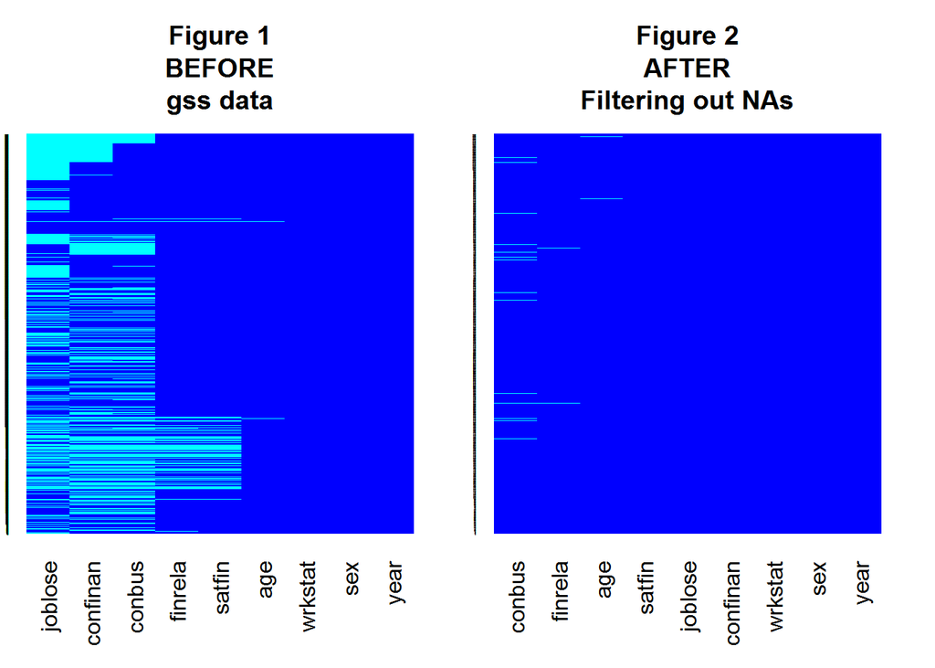

Figure 2: After filtering out rows where features confinan AND joblose contain NA. This leaves us with a dataset of 10,978. It is interesting to note that confinan and joblose NAs appear to be related in some way because removing where they BOTH are NAs has removed ALL NAs from either one. Looks promising. Let’s continue with some inference on this dataset.

#### Step 4 - At a high level let’s see how the variables of interest confinan and joblose are related to each other.

```r
df.gss06<-df.gss[df.gss$year %in% c(2004,2006),]
df.gss08<-df.gss[df.gss$year >= 2008,]
#No joblose = Leaving Labor Force in 2004-2012 so get rid of it.
df.gss06$joblose<-factor(df.gss06$joblose)
df.gss08$joblose<-factor(df.gss08$joblose)
#
dim(df.gss06) #Final Size of Analysis Dataset for the years 2004-2006
```

```
## [1] 868   9
```

```r
#
dim(df.gss08) #Final Size of Analysis Dataset for the years 2010-2012
```

```
## [1] 1229    9
```

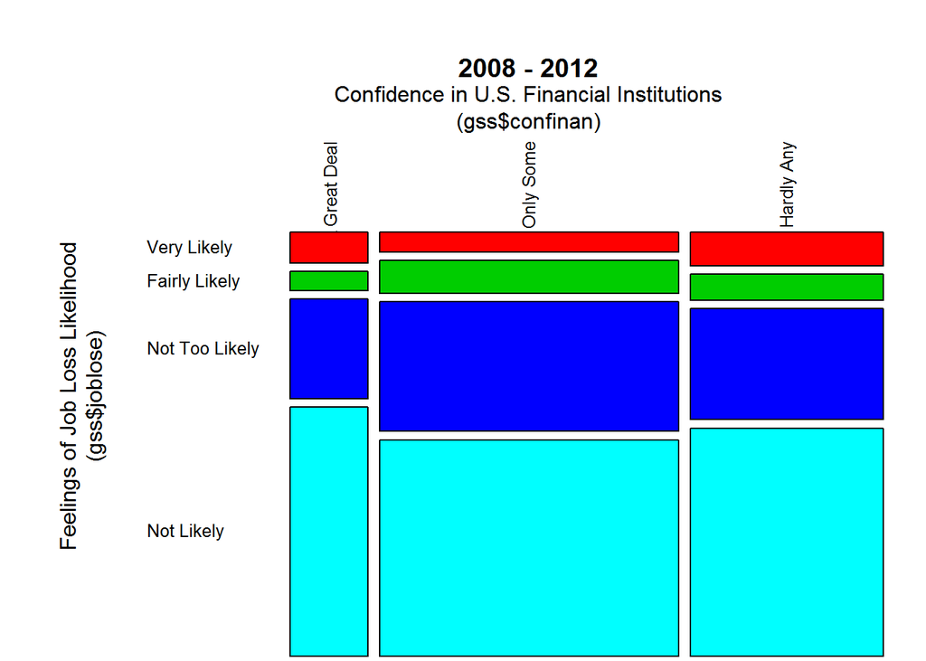

There is some almost imperceptible deviation within the groups but is it statistically significant? A large deviation from what is expected from chance alone, would suggest that there is a relationship between the two features. However, if there is such deviation it isn’t very pronounced. Therefore, we would expect a p-value that would be close to the 0.05 signficance level.

### Part 4 Inference:

#### Are the differences between the two groups statistically significant?

- It is assumed and stated above that the gss survey is a random sample. Each case/observation is independent of every other.
- Each case contributes to one cell in the following table.

```r
Total<-sum #Function call for addmargins below. Purely cosmetic
kable(addmargins(table(df.gss08$joblose,df.gss08$confinan),FUN = Total,quiet=T))
```

|  | A Great Deal | Only Some | Hardly Any | Total |
| --- | --- | --- | --- | --- |
| Very Likely | 13 | 32 | 35 | 80 |
| Fairly Likely | 8 | 53 | 27 | 88 |
| Not Too Likely | 42 | 210 | 116 | 368 |
| Not Likely | 105 | 350 | 238 | 693 |
| Total | 168 | 645 | 416 | 1229 |

- There are more than 5 expected cases in each cell.

##### Chi-square Test of Independence

The theorectical requirements have been met to use the Chi-squared Test for Independence. This test will be used because we are dealing with the relatinoship of two categorical variables, each of which has more than 2 levels.

- **Null Hypothesis ($H_0$)**

Job security is not related to Respondents’ confidence in U.S. Financial Institutions.

- **Alternative Hypothesis ($H_A$)**

Job security IS related to a Respondent’s confidence in U.S. Financial Institutions. The two are related in some fashion. Job security is affected by a Respondent’s attitude towards U.S. Financial Instituions.

```r
chisq.test(df.gss08$confinan,df.gss08$joblose)
```

```
##
##  Pearson's Chi-squared test
##
## data:  df.gss08$confinan and df.gss08$joblose
## X-squared = 12.8098, df = 6, p-value = 0.04616
```

The chi-square statistic ($X^2$) is 12.8098 with 6 degrees of freedom (df=6). The data provide not very convincing evidence that if there were no relationship between a Respondent’s confidence in U.S. financial Insitutions and their feelings of job security, it would be unusual to see a chi-square statistic at least as extreme as 12.8098. Therefore we reject the null hypothesis in favor of the alternative.

### Part 5 Conclusion:

This analysis tested the hypothesis that a Respondent’s feelings of job security is related to their feelings about the U.S. Financial Insitutions at the 5% signficance level using a Chi-squared Test for Independence. We found a p-value of 0.04616. Oh so close! This p-value is less than 0.05 so we reject the NULL Hypothesis in favor of the Alternative hypothesis that the two variables ARE related. BUT it is too close to be very comfortable with this conclusion. Further analysis is necessary. It is worthwhile to do this same analysis on data in the years pre-2007/2008 Financial crisis and compare that result to this one.

Here is the same test on the two years directly before the financial crisis. A reasonable assumption might be that a Respondent to the gss survey did not relate as strongly their own job security with their confidence in U.S. Financial Insitutions before the crisis as after. One would think that such a catastrophic event, so mercilessly covered in the media would have a substantial negative effect. Especially since the unemployment rate spiked atfer the Financial Crisis of 2007/2008.

```r
chisq.test(df.gss06$confinan,df.gss06$joblose)
```

```
##
##  Pearson's Chi-squared test
##
## data:  df.gss06$confinan and df.gss06$joblose
## X-squared = 20.0164, df = 6, p-value = 0.002751
```

But with a p-value of 0.002751, the two appear even more related BEFORE the crisis than after. This suggests there are confounding variables that are affecting feelings about job security. Reasons other than confidence in U.S. Financial Insitutions because it would seem reasonable that people would be focussed on the financial crisis and this would in turn affect their feelings of job security.

### Appendix - Example Data

```r
subset(df.gss08,select=c("year","wrkstat","confinan","joblose"))[1:15,]
```

```
##       year          wrkstat     confinan        joblose
## 51023 2008 Working Fulltime    Only Some  Fairly Likely
## 51028 2008 Working Fulltime A Great Deal Not Too Likely
## 51031 2008 Working Fulltime    Only Some     Not Likely
## 51048 2008 Working Fulltime    Only Some Not Too Likely
## 51056 2008 Working Fulltime A Great Deal Not Too Likely
## 51068 2008 Working Fulltime    Only Some Not Too Likely
## 51069 2008 Temp Not Working    Only Some     Not Likely
## 51070 2008 Working Fulltime    Only Some     Not Likely
## 51071 2008 Working Fulltime   Hardly Any     Not Likely
## 51075 2008 Working Fulltime   Hardly Any     Not Likely
## 51076 2008 Working Fulltime A Great Deal     Not Likely
## 51077 2008 Working Fulltime    Only Some     Not Likely
## 51080 2008 Working Fulltime    Only Some Not Too Likely
## 51083 2008 Working Fulltime A Great Deal Not Too Likely
## 51094 2008 Working Fulltime    Only Some     Not Likely
```

### References:

#### Data URL

http://bit.ly/dasi_gss_data

#### Data Citation

[1]Smith, Tom W., Michael Hout, and Peter V. Marsden. General Social Survey, 1972-2012 [Cumulative File]. ICPSR34802-v1. Storrs, CT: Roper Center for Public Opinion Research, University of Connecticut /Ann Arbor, MI: Inter-university Consortium for Political and Social Research [distributors], 2013-09-11. doi:10.3886/ICPSR34802.v1

Persistent URL: http://doi.org/10.3886/ICPSR34802.v1

[2] http://www.du.edu/idea/director/about-gss.html

#### Other Citations

[3] US Business Cycle Expansions and Contractions, NBER, accessed August 9, 2012. http://www.nber.org/cycles.html

[4]Financial Inquiry Commission-Final Report-Retrieved February 2013. http://fcic.law.stanford.edu/report